# Spotify Music Popularity Analysis

## Project Overview

This project analyzes Spotify track data to investigate which musical characteristics are most associated with song popularity. The analysis combines exploratory data analysis, unsupervised clustering, and classification modeling to examine patterns across genre and continuous audio features including danceability, energy, loudness, tempo, key, and duration.

### Objective

The primary objective is to classify whether a track reaches a defined popularity threshold and identify which features contribute most strongly to differences between more- and less-popular songs.

### Analytical Approach

The project includes:

- Data cleaning and feature preparation
- Exploratory analysis of track characteristics and popularity
- Visualization of relationships among continuous and categorical variables
- KMeans clustering to identify groups of tracks with similar audio characteristics
- Classification modeling and model evaluation
- Comparison of findings across EDA, clustering, and predictive modeling

### Tools & Methods

**Python • Pandas • Matplotlib • Seaborn • scikit-learn • Logistic Regression • KMeans Clustering • PCA**

Methods include data cleaning, feature engineering, exploratory data analysis, correlation analysis, feature standardization, cluster evaluation, principal component analysis, categorical encoding, pipeline construction, stratified cross-validation, classification evaluation, and model interpretation.

# Exploratory Data Analysis

## Data Preparation and Initial Exploration

```python
# Core data and visualization libraries
import numpy as np
import pandas as pd
import matplotlib.pyplot as plt
import seaborn as sns

# Data preparation and machine learning
from sklearn.preprocessing import StandardScaler, OneHotEncoder
from sklearn.cluster import KMeans
from sklearn.decomposition import PCA
from sklearn.compose import ColumnTransformer
from sklearn.model_selection import (train_test_split, StratifiedKFold, cross_val_score)
from sklearn.linear_model import LogisticRegression
from sklearn.pipeline import Pipeline
from sklearn.metrics import silhouette_score

# Model evaluation
from sklearn.metrics import (confusion_matrix, roc_curve, auc, roc_auc_score, accuracy_score, precision_score, recall_score, f1_score)
```

```python
songs_url = 'https://raw.githubusercontent.com/rfordatascience/tidytuesday/master/data/2020/2020-01-21/spotify_songs.csv'
df = pd.read_csv(songs_url)
```

### Dataset Dimensions

```python
df.shape
```

```
(32833, 23)
```

### Available Features

```python
df.columns
```

```
Index(['track_id', 'track_name', 'track_artist', 'track_popularity',
       'track_album_id', 'track_album_name', 'track_album_release_date',
       'playlist_name', 'playlist_id', 'playlist_genre', 'playlist_subgenre',
       'danceability', 'energy', 'key', 'loudness', 'mode', 'speechiness',
       'acousticness', 'instrumentalness', 'liveness', 'valence', 'tempo',
       'duration_ms'],
      dtype='str')
```

### Data Types

```python
df.info()
```

```
<class 'pandas.DataFrame'>
RangeIndex: 32833 entries, 0 to 32832
Data columns (total 23 columns):
 #   Column                    Non-Null Count  Dtype
---  ------                    --------------  -----
 0   track_id                  32833 non-null  str
 1   track_name                32828 non-null  str
 2   track_artist              32828 non-null  str
 3   track_popularity          32833 non-null  int64
 4   track_album_id            32833 non-null  str
 5   track_album_name          32828 non-null  str
 6   track_album_release_date  32833 non-null  str
 7   playlist_name             32833 non-null  str
 8   playlist_id               32833 non-null  str
 9   playlist_genre            32833 non-null  str
 10  playlist_subgenre         32833 non-null  str
 11  danceability              32833 non-null  float64
 12  energy                    32833 non-null  float64
 13  key                       32833 non-null  int64
 14  loudness                  32833 non-null  float64
 15  mode                      32833 non-null  int64
 16  speechiness               32833 non-null  float64
 17  acousticness              32833 non-null  float64
 18  instrumentalness          32833 non-null  float64
 19  liveness                  32833 non-null  float64
 20  valence                   32833 non-null  float64
 21  tempo                     32833 non-null  float64
 22  duration_ms               32833 non-null  int64
dtypes: float64(9), int64(4), str(10)
memory usage: 5.8 MB
```

### Missing Values

```python
df.isna().sum()
```

```
track_id                    0
track_name                  5
track_artist                5
track_popularity            0
track_album_id              0
track_album_name            5
track_album_release_date    0
playlist_name               0
playlist_id                 0
playlist_genre              0
playlist_subgenre           0
danceability                0
energy                      0
key                         0
loudness                    0
mode                        0
speechiness                 0
acousticness                0
instrumentalness            0
liveness                    0
valence                     0
tempo                       0
duration_ms                 0
dtype: int64
```

### Unique Values

```python
df.nunique()
```

```
track_id                    28356
track_name                  23449
track_artist                10692
track_popularity              101
track_album_id              22545
track_album_name            19743
track_album_release_date     4530
playlist_name                 449
playlist_id                   471
playlist_genre                  6
playlist_subgenre              24
danceability                  822
energy                        952
key                            12
loudness                    10222
mode                            2
speechiness                  1270
acousticness                 3731
instrumentalness             4729
liveness                     1624
valence                      1362
tempo                       17684
duration_ms                 19785
dtype: int64
```

### Data Cleaning

Initial inspection identified a small number of missing values in track-related fields. Missing records and duplicate tracks were removed before preparing the dataset for analysis.

```python
df.dropna(axis = 0, how = 'any', inplace = True, ignore_index = False)
```

```python
df.drop_duplicates(subset = ['track_id'],keep = 'first', inplace = True, ignore_index = False)
```

```python
df['duration_min'] = (df['duration_ms'] // 60000) + (df['duration_ms'] % 60000) / 60000
```

```python
df['key'] = df['key'].astype('category')
```

### Popularity Thresholds

The original exploratory analysis categorized popularity using quartiles. For the classification analysis, I replaced that approach with three binary popularity thresholds at scores greater than 50, 60, and 70.

Using multiple thresholds allowed the analysis to compare whether relationships between track characteristics and popularity remained consistent as the definition of a popular track became more selective.

```python
df['track_pop_50'] = np.where(df.track_popularity > 50, 1, 0)
```

```python
df['track_pop_60'] = np.where(df.track_popularity > 60, 1, 0)
```

```python
df['track_pop_70'] = np.where(df.track_popularity > 70, 1, 0)
```

### Feature Selection

The dataset was reduced to the variables used in the analysis: track popularity, playlist genre, key, danceability, energy, loudness, tempo, and duration, along with the engineered popularity-threshold variables.

```python
df.drop(['track_id', 'track_name', 'track_artist', 'track_album_id', 'track_album_name', 'track_album_release_date',
         'playlist_name', 'playlist_id', 'playlist_subgenre', 'mode', 'speechiness', 'acousticness',
         'instrumentalness', 'liveness', 'valence', 'duration_ms'],axis = 1, inplace = True)
```

```python
df.info()
```

```
<class 'pandas.DataFrame'>
Index: 28352 entries, 0 to 32832
Data columns (total 11 columns):
 #   Column            Non-Null Count  Dtype
---  ------            --------------  -----
 0   track_popularity  28352 non-null  int64
 1   playlist_genre    28352 non-null  str
 2   danceability      28352 non-null  float64
 3   energy            28352 non-null  float64
 4   key               28352 non-null  category
 5   loudness          28352 non-null  float64
 6   tempo             28352 non-null  float64
 7   duration_min      28352 non-null  float64
 8   track_pop_50      28352 non-null  int64
 9   track_pop_60      28352 non-null  int64
 10  track_pop_70      28352 non-null  int64
dtypes: category(1), float64(5), int64(4), str(1)
memory usage: 2.4 MB
```

```python
df.shape
```

```
(28352, 11)
```

## Exploratory Visualizations

### Categorical and Target Distributions

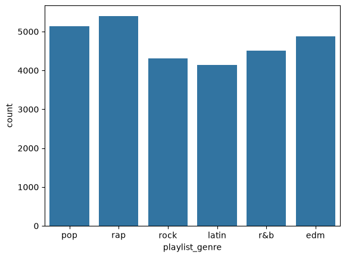

```python
fig, ax = plt.subplots()
sns.countplot(data = df, x = 'playlist_genre', ax = ax)
plt.show()
```

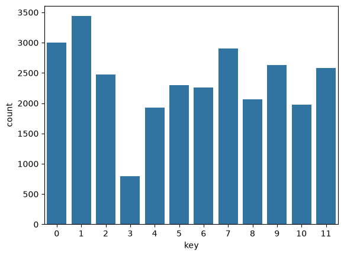

```python
fig, ax = plt.subplots()
sns.countplot(data = df, x = 'key', ax = ax)
plt.show()
```

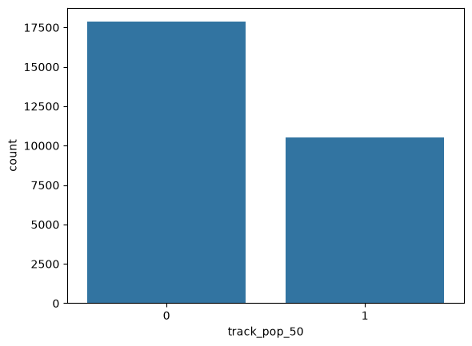

```python
fig, ax = plt.subplots()
sns.countplot(data = df, x = 'track_pop_50', ax = ax)
plt.show()
```

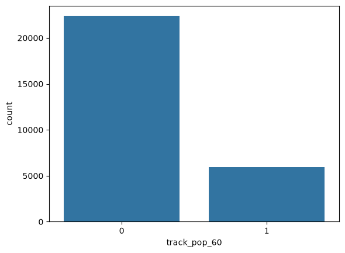

```python
fig, ax = plt.subplots()
sns.countplot(data = df,x = 'track_pop_60',ax = ax)
plt.show()
```

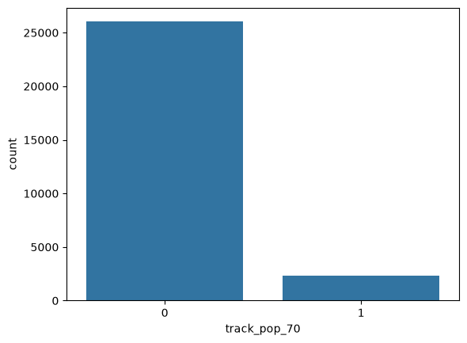

```python
fig, ax = plt.subplots()
sns.countplot(data = df,x = 'track_pop_70',ax = ax)
plt.show()
```

The popularity threshold greater than 50 produces the most balanced class distribution of the three candidate targets. The greater-than-60 and greater-than-70 thresholds become progressively more imbalanced, making the greater-than-50 target the strongest candidate for the classification models evaluated later in the analysis.

### Continuous Feature Distributions

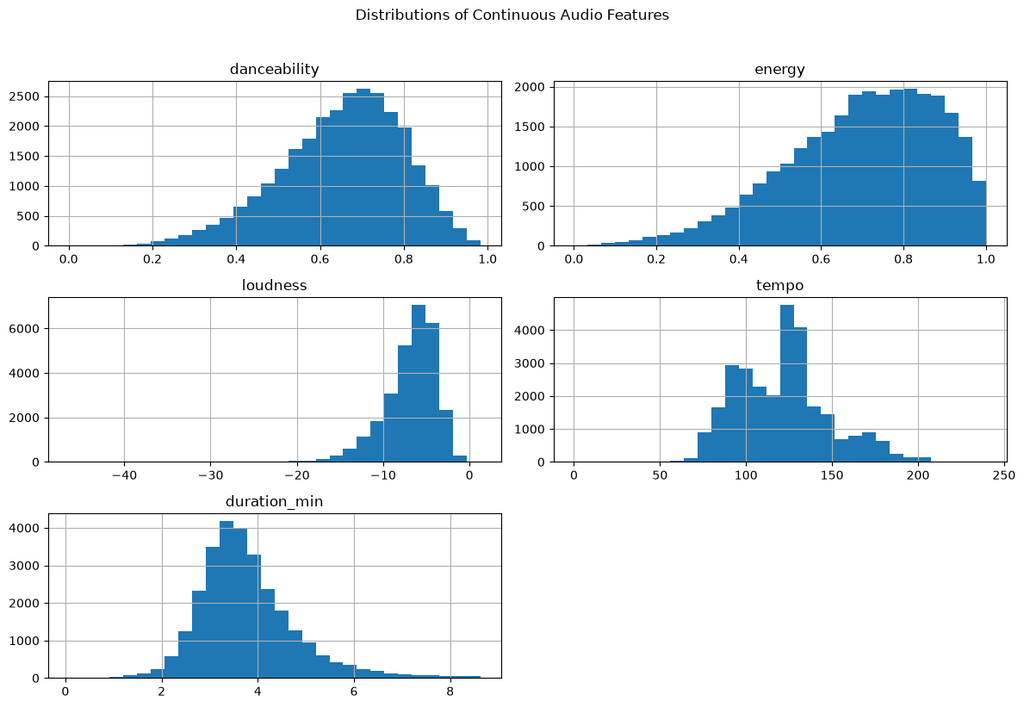

```python
# Select the continuous audio features used in the analysis

continuous_features = ['danceability', 'energy', 'loudness',
                       'tempo', 'duration_min']

# Plot the distribution of each continuous feature

df[continuous_features].hist(figsize = (12, 8), bins = 30)

plt.suptitle('Distributions of Continuous Audio Features', y = 1.02)

plt.tight_layout()
plt.show()
```

### Relationships Among Continuous Features

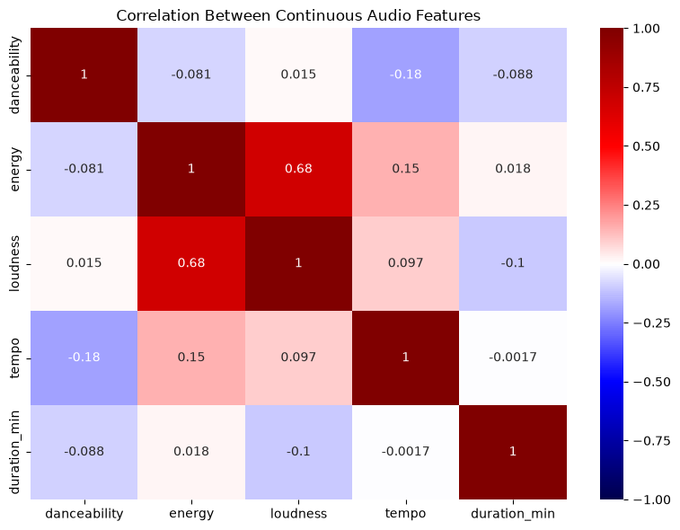

```python
# Calculate correlations between the continuous audio features

correlation_matrix = df[continuous_features].corr()

plt.figure(figsize = (8, 6))

sns.heatmap(correlation_matrix, vmin = -1, vmax = 1, center = 0,
            cmap = 'seismic', annot = True)

plt.title('Correlation Between Continuous Audio Features')
plt.tight_layout()
plt.show()
```

Energy and loudness show the strongest relationship among the continuous audio features. The remaining feature pairs show substantially weaker linear relationships, making the energy-loudness relationship particularly important to examine further during clustering and predictive modeling.

### Audio Features by Playlist Genre

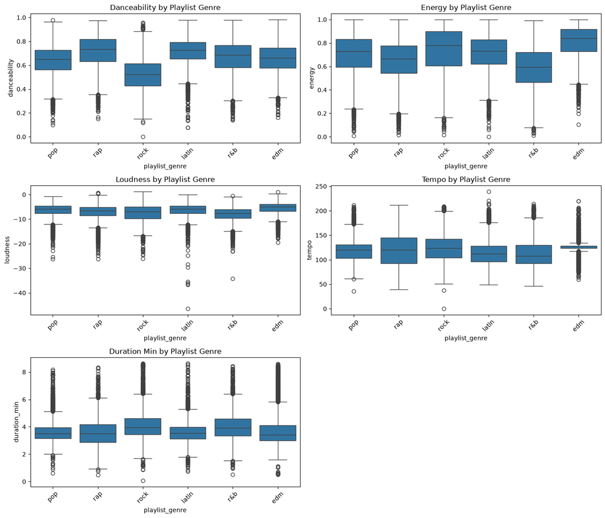

```python
# Compare continuous features across playlist genres

fig, ax = plt.subplots(3, 2, figsize = (14, 12))

for axis, feature in zip(ax.flat, continuous_features):
    sns.boxplot(data = df, x = 'playlist_genre', y = feature, ax = axis)

    axis.set_title(f'{feature.replace("_", " ").title()} by Playlist Genre')
    axis.tick_params(axis = 'x', rotation = 45)

# Hide the unused sixth plot
ax.flat[-1].axis('off')

plt.tight_layout()
plt.show()
```

### Energy and Loudness Relationship

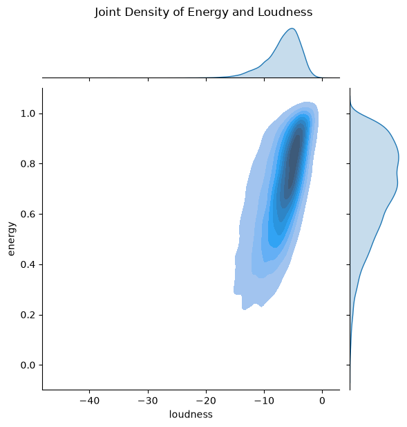

```python
# Examine the relationship between loudness and energy

sns.jointplot(data = df, x = 'loudness', y = 'energy',
              kind = 'kde', fill = True)

plt.suptitle('Joint Density of Energy and Loudness', y = 1.02)

plt.show()
```

The joint-density visualization reinforces the correlation analysis: tracks with higher energy also tend to have higher loudness. This relationship becomes relevant later when evaluating clustering patterns and predictive-model features.

### Audio Features by Popularity Class

After comparing the three candidate popularity thresholds, the greater-than-50 target was selected for further classification analysis because it provided the most balanced outcome distribution. The continuous audio features are compared below for tracks on either side of that threshold.

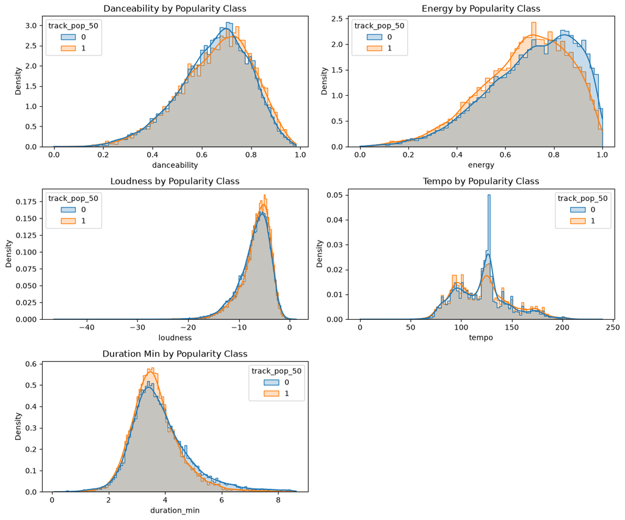

```python
# Compare each continuous feature by popularity class

fig, ax = plt.subplots(3, 2, figsize = (12, 10))

for axis, feature in zip(ax.flat, continuous_features):
    sns.histplot(data = df, x = feature, hue = 'track_pop_50',
                 kde = True, element = 'step', stat = 'density',
                 common_norm = False, ax = axis)

    axis.set_title(f'{feature.replace("_", " ").title()} by Popularity Class')

# Hide the unused sixth plot
ax.flat[-1].axis('off')

plt.tight_layout()
plt.show()
```

The continuous features show substantial overlap between the two popularity classes, indicating that no single audio characteristic cleanly separates popular from less-popular tracks. Energy and loudness continue to show some of the more noticeable differences, supporting their inclusion in the later modeling analysis.

### Categorical Features and Popularity

Popularity rates were compared across playlist genre and musical key using the greater-than-50 classification target.

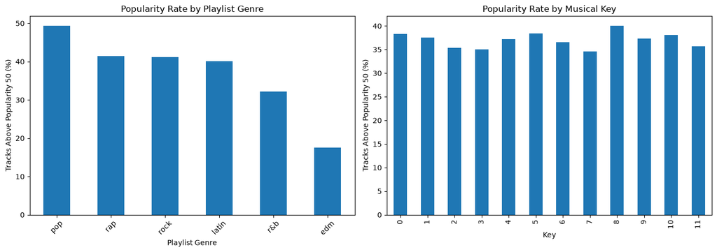

```python
# Calculate the percentage of tracks above the popularity threshold
# for each genre and musical key

genre_pop = df.groupby('playlist_genre')['track_pop_50'].mean() * 100
genre_pop = genre_pop.sort_values(ascending = False)

key_pop = df.groupby('key', observed = True)['track_pop_50'].mean() * 100

# Compare popularity rates across the two categorical features

fig, ax = plt.subplots(1, 2, figsize = (14, 5))

genre_pop.plot(kind = 'bar', ax = ax[0])
ax[0].set_title('Popularity Rate by Playlist Genre')
ax[0].set_xlabel('Playlist Genre')
ax[0].set_ylabel('Tracks Above Popularity 50 (%)')
ax[0].tick_params(axis = 'x', rotation = 45)

key_pop.plot(kind = 'bar', ax = ax[1])
ax[1].set_title('Popularity Rate by Musical Key')
ax[1].set_xlabel('Key')
ax[1].set_ylabel('Tracks Above Popularity 50 (%)')

plt.tight_layout()
plt.show()
```

Genre shows more pronounced differences in popularity rates than musical key, providing an early indication that genre may be more useful for predicting whether a track exceeds the popularity threshold.

### Popularity Threshold Model Comparison

A preliminary logistic regression model was used to compare the three candidate popularity thresholds using the continuous audio features. Confusion matrices show how each threshold performs as a binary classification problem, while ROC curves compare the model's ability to distinguish between the two classes.

This comparison helps evaluate which popularity threshold is most appropriate for the more detailed modeling that follows.

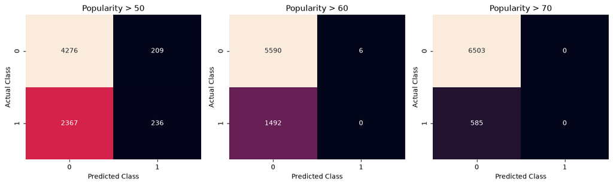

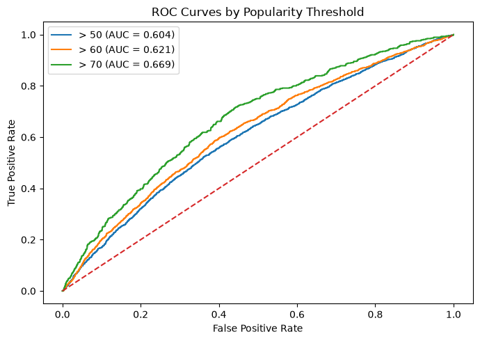

```python
# Compare preliminary classification performance across the three popularity thresholds

outcomes = ['track_pop_50', 'track_pop_60', 'track_pop_70']

fig, ax = plt.subplots(1, 3, figsize = (13, 4))
fig_roc, ax_roc = plt.subplots(figsize = (7, 5))

for i, outcome in enumerate(outcomes):

    X = df[continuous_features]
    y = df[outcome]

    # Use the same train/test split for each popularity threshold

    X_train, X_test, y_train, y_test = train_test_split(
        X, y, test_size = 0.25, random_state = 113)

    # Fit preliminary logistic regression model

    model = LogisticRegression(max_iter = 500)
    model.fit(X_train, y_train)

    y_pred = model.predict(X_test)
    y_prob = model.predict_proba(X_test)[:, 1]

    # Confusion matrix

    cm = confusion_matrix(y_test, y_pred)

    sns.heatmap(cm, annot = True, fmt = 'd', cbar = False, ax = ax[i])

    ax[i].set_title(outcome.replace('track_pop_', 'Popularity > '))
    ax[i].set_xlabel('Predicted Class')
    ax[i].set_ylabel('Actual Class')

    # ROC curve and AUC

    fpr, tpr, _ = roc_curve(y_test, y_prob)
    roc_auc = auc(fpr, tpr)

    ax_roc.plot(fpr, tpr,
                label = f'{outcome.replace("track_pop_", "> ")} (AUC = {roc_auc:.3f})')

# Add reference line for random classification

ax_roc.plot([0, 1], [0, 1], '--')
ax_roc.set_title('ROC Curves by Popularity Threshold')
ax_roc.set_xlabel('False Positive Rate')
ax_roc.set_ylabel('True Positive Rate')
ax_roc.legend()

fig.tight_layout()
fig_roc.tight_layout()

plt.show()
```

The classification results reinforce the class-balance differences identified earlier. The greater-than-60 and greater-than-70 targets become increasingly difficult to classify, with the preliminary models predicting very few or no positive cases at the higher thresholds.

The greater-than-50 target provides a substantially more workable class distribution and was therefore selected as the outcome for the more detailed classification modeling later in the analysis.

# Clustering Analysis

KMeans clustering was used to identify groups of tracks with similar continuous audio characteristics. The analysis uses danceability, loudness, energy, tempo, and duration.

```python
# Create the dataset used for clustering

df_cluster = df[['danceability', 'loudness', 'energy',
                 'tempo', 'duration_min']].copy()

# Transform tempo and duration based on their observed distributions

df_cluster['tempo'] = np.log1p(df_cluster['tempo'])
df_cluster['duration_min'] = np.log1p(df_cluster['duration_min'])

# Standardize features so each variable contributes on a comparable scale

X = StandardScaler().fit_transform(df_cluster)
```

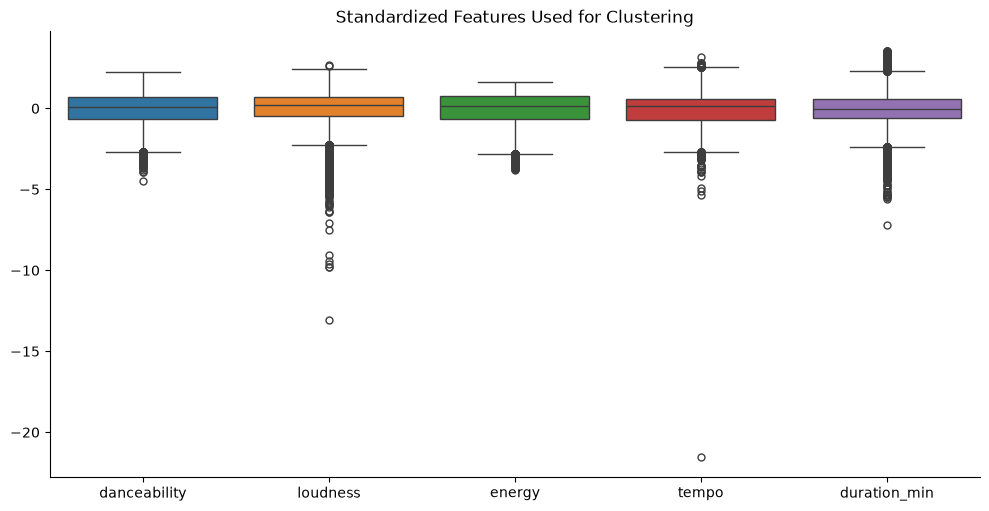

```python
# Confirm the clustering features are on comparable scales

df_scaled = pd.DataFrame(X, columns = df_cluster.columns)

sns.catplot(data = df_scaled, kind = 'box', aspect = 2)

plt.title('Standardized Features Used for Clustering')
plt.show()
```

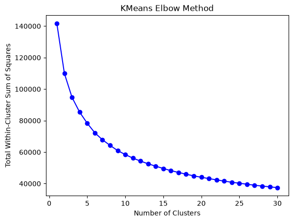

```python
# Compare within-cluster variation across possible values of k

tots_within = []
K = range(1, 31)

for k in K:
    km = KMeans(n_clusters = k, random_state = 113,
                n_init = 25, max_iter = 500)

    km.fit(X)
    tots_within.append(km.inertia_)

# Plot the elbow curve

fig, ax = plt.subplots()

ax.plot(K, tots_within, 'bo-')
ax.set_xlabel('Number of Clusters')
ax.set_ylabel('Total Within-Cluster Sum of Squares')
ax.set_title('KMeans Elbow Method')

plt.show()
```

```python
# Compare cluster separation for several possible values of k

silhouette_scores = []
K_test = range(2, 9)

for k in K_test:
    km = KMeans(n_clusters = k, random_state = 113,
                n_init = 25, max_iter = 500)

    cluster_labels = km.fit_predict(X)
    silhouette_scores.append(silhouette_score(X, cluster_labels))

# Display the silhouette score for each value of k

silhouette_results = pd.DataFrame({
    'Clusters': list(K_test),
    'Silhouette Score': silhouette_scores
})

silhouette_results
```

|  | Clusters | Silhouette Score |
| --- | --- | --- |
| 0 | 2 | 0.232639 |
| 1 | 3 | 0.175914 |
| 2 | 4 | 0.172111 |
| 3 | 5 | 0.169031 |
| 4 | 6 | 0.167672 |
| 5 | 7 | 0.169514 |
| 6 | 8 | 0.169532 |

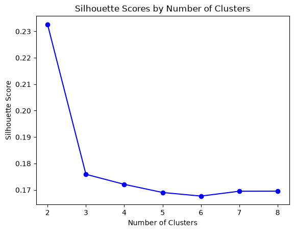

```python
# Visualize the silhouette scores

fig, ax = plt.subplots()

ax.plot(K_test, silhouette_scores, 'bo-')
ax.set_xlabel('Number of Clusters')
ax.set_ylabel('Silhouette Score')
ax.set_title('Silhouette Scores by Number of Clusters')

plt.show()
```

```python
# Compare popularity results for the 2 and 4 cluster solutions

for k in [2, 4]:

    km = KMeans(n_clusters = k, random_state = 113,
                n_init = 25, max_iter = 500)

    cluster_labels = km.fit_predict(X)

    df_compare = df[['track_popularity', 'track_pop_50']].copy()
    df_compare['cluster'] = cluster_labels

    cluster_results = df_compare.groupby('cluster').agg(
        avg_popularity = ('track_popularity', 'mean'),
        popular_rate = ('track_pop_50', 'mean'),
        track_count = ('track_pop_50', 'count'))

    cluster_results['popular_rate'] = cluster_results['popular_rate'] * 100

    print(f'\n{k} Cluster Solution')
    display(cluster_results.round(2))
```

```
2 Cluster Solution
```

| cluster | avg_popularity | popular_rate | track_count |
| --- | --- | --- | --- |
| 0 | 39.89 | 37.43 | 10595 |
| 1 | 39.00 | 36.83 | 17757 |

```
4 Cluster Solution
```

| cluster | avg_popularity | popular_rate | track_count |
| --- | --- | --- | --- |
| 0 | 38.18 | 35.76 | 8135 |
| 1 | 33.75 | 29.00 | 5300 |
| 2 | 42.58 | 41.72 | 9927 |
| 3 | 40.70 | 38.44 | 4990 |

### Cluster Selection

Silhouette analysis produced the highest score for a two-cluster solution, although overall silhouette values indicated substantial overlap among tracks.

Although the two-cluster solution produced the highest silhouette score, it separated tracks primarily into broad audio profiles with almost identical observed popularity rates. A four-cluster solution was retained as a more granular exploratory segmentation because it produced more distinct audio profiles and a wider range of observed popularity rates.

The four-cluster solution is therefore used for interpretation rather than presented as the mathematically optimal clustering solution.

```python
# Fit the final four-cluster KMeans solution

cluster_4 = KMeans(n_clusters = 4, random_state = 113,
                   n_init = 25, max_iter = 500)

cluster_labels = cluster_4.fit_predict(X)

# Add cluster assignments to the original analysis data

df_cluster_final = df[continuous_features +
                      ['track_popularity', 'track_pop_50']].copy()

df_cluster_final['cluster'] = cluster_labels
```

```python
# Summarize the audio characteristics and popularity of each cluster

cluster_summary = df_cluster_final.groupby('cluster').agg(
    danceability = ('danceability', 'mean'),
    energy = ('energy', 'mean'),
    loudness = ('loudness', 'mean'),
    tempo = ('tempo', 'mean'),
    duration_min = ('duration_min', 'mean'),
    avg_popularity = ('track_popularity', 'mean'),
    popular_rate = ('track_pop_50', 'mean'),
    track_count = ('track_pop_50', 'count'))

cluster_summary['popular_rate'] = cluster_summary['popular_rate'] * 100

cluster_summary.round(2)
```

| cluster | danceability | energy | loudness | tempo | duration_min | avg_popularity | popular_rate | track_count |
| --- | --- | --- | --- | --- | --- | --- | --- | --- |
| 0 | 0.54 | 0.83 | -5.08 | 141.82 | 3.66 | 38.18 | 35.76 | 8135 |
| 1 | 0.67 | 0.69 | -7.65 | 112.93 | 5.14 | 33.75 | 29.00 | 5300 |
| 2 | 0.75 | 0.73 | -5.64 | 111.28 | 3.27 | 42.58 | 41.72 | 9927 |
| 3 | 0.63 | 0.43 | -11.12 | 114.72 | 3.53 | 40.70 | 38.44 | 4990 |

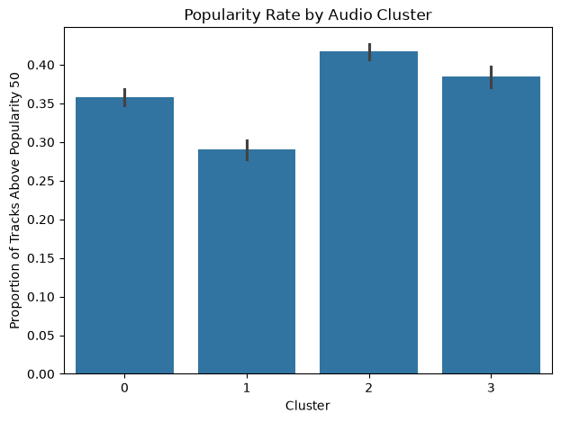

```python
# Compare the observed popularity rate across clusters

fig, ax = plt.subplots(figsize = (7, 5))

sns.barplot(data = df_cluster_final, x = 'cluster',
            y = 'track_pop_50', ax = ax)

ax.set_title('Popularity Rate by Audio Cluster')
ax.set_xlabel('Cluster')
ax.set_ylabel('Proportion of Tracks Above Popularity 50')

plt.show()
```

### Cluster Interpretation

The four-cluster solution identified distinct combinations of audio characteristics with different observed popularity rates.

Cluster 2 contained the most danceable tracks and relatively high energy and loudness, and had the highest proportion of tracks above the popularity threshold at approximately 41.7%. Cluster 1 contained the longest tracks and had the lowest popularity rate at approximately 29.0%.

The differences across clusters support the broader finding that combinations of audio characteristics are associated with popularity, while also showing that no single cluster profile determines whether a track will be popular.

### Cluster Visualization with PCA

Principal component analysis was used to reduce the standardized clustering features to two dimensions so the four-cluster solution could be visualized more easily.

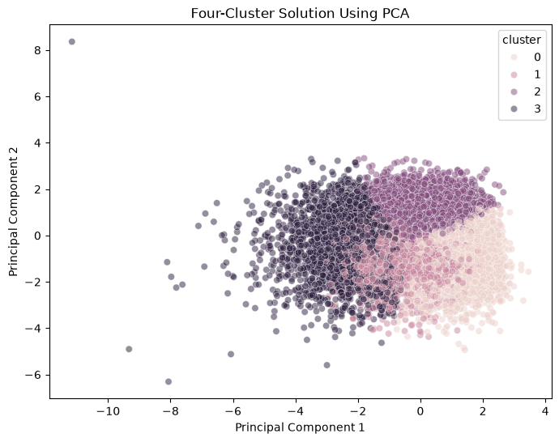

```python
# Reduce the standardized clustering data to two dimensions for visualization

pca = PCA(n_components = 2)
pca_values = pca.fit_transform(X)

pca_df = pd.DataFrame(pca_values, columns = ['PC1', 'PC2'])
pca_df['cluster'] = cluster_labels

# Visualize the four audio clusters

fig, ax = plt.subplots(figsize = (8, 6))

sns.scatterplot(data = pca_df, x = 'PC1', y = 'PC2',
                hue = 'cluster', alpha = 0.5, ax = ax)

ax.set_title('Four-Cluster Solution Using PCA')
ax.set_xlabel('Principal Component 1')
ax.set_ylabel('Principal Component 2')

plt.show()
```

The PCA visualization shows substantial overlap among the tracks, which is consistent with the relatively low silhouette scores. The clusters therefore represent broad audio profiles rather than sharply separated groups.

# Classification Modeling

The exploratory and clustering analyses showed that track characteristics contain some information related to popularity, but no individual feature cleanly separates popular from less-popular tracks.

The classification analysis therefore combines continuous audio features with playlist genre and musical key to predict whether a track has a popularity score greater than 50.

```python
# Define the features and classification target

categorical_features = ['playlist_genre', 'key']
model_features = continuous_features + categorical_features

X_model = df[model_features]
y = df['track_pop_50']

# Create a stratified train/test split to preserve the outcome distribution

X_train, X_test, y_train, y_test = train_test_split(
    X_model, y, test_size = 0.25, random_state = 113,
    stratify = y)

print('Training observations:', len(X_train))
print('Testing observations:', len(X_test))
```

```
Training observations: 21264
Testing observations: 7088
```

## Model Preprocessing

Continuous features are standardized before modeling, while the categorical variables are converted to indicator variables using one-hot encoding. A scikit-learn pipeline keeps preprocessing and model fitting together so the same transformations are applied consistently during training, validation, and prediction.

```python
# Prepare continuous and categorical features for modeling

preprocessor = ColumnTransformer(transformers = [
    ('continuous', StandardScaler(), continuous_features),
    ('categorical', OneHotEncoder(handle_unknown = 'ignore',
                                  drop = 'first'), categorical_features)
])

# Create the logistic regression pipeline

full_model = Pipeline(steps = [
    ('preprocessor', preprocessor),
    ('classifier', LogisticRegression(max_iter = 1000))
])
```

## Model Comparison

Two logistic regression models were compared using stratified five-fold cross-validation. The first model uses only the continuous audio features, while the second adds playlist genre and musical key.

ROC AUC and accuracy are used to compare their ability to classify tracks above the popularity threshold.

```python
# Create a model using only the continuous audio features

continuous_model = Pipeline(steps = [
    ('scaler', StandardScaler()),
    ('classifier', LogisticRegression(max_iter = 1000))
])

# Use stratified cross-validation because the classification outcome is imbalanced

cv = StratifiedKFold(n_splits = 5, shuffle = True, random_state = 113)

# Evaluate the continuous-only model

continuous_auc = cross_val_score(
    continuous_model, X_train[continuous_features], y_train,
    cv = cv, scoring = 'roc_auc')

continuous_accuracy = cross_val_score(
    continuous_model, X_train[continuous_features], y_train,
    cv = cv, scoring = 'accuracy')

# Evaluate the model containing continuous and categorical features

full_auc = cross_val_score(
    full_model, X_train, y_train,
    cv = cv, scoring = 'roc_auc')

full_accuracy = cross_val_score(
    full_model, X_train, y_train,
    cv = cv, scoring = 'accuracy')
```

```python
# Summarize cross-validation performance

model_comparison = pd.DataFrame({
    'Model': ['Continuous Features', 'Continuous + Categorical'],
    'Mean Accuracy': [continuous_accuracy.mean(), full_accuracy.mean()],
    'Mean ROC AUC': [continuous_auc.mean(), full_auc.mean()]
})

model_comparison.round(3)
```

|  | Model | Mean Accuracy | Mean ROC AUC |
| --- | --- | --- | --- |
| 0 | Continuous Features | 0.631 | 0.603 |
| 1 | Continuous + Categorical | 0.644 | 0.659 |

### Model Comparison Findings

Adding the categorical features improved model performance compared with using the continuous audio features alone.

Mean accuracy increased from 0.631 to 0.644, while mean ROC AUC increased from 0.603 to 0.659. The larger improvement in ROC AUC suggests that playlist genre and musical key add useful information for distinguishing between tracks above and below the popularity threshold.

The improvement is meaningful but still modest, indicating that popularity is only partially explained by the available audio and categorical features.

## Final Logistic Regression Model

The full logistic regression model combines the continuous audio characteristics with playlist genre and musical key. The model is trained on the training data and evaluated using the held-out test set.

```python
# Fit the final model

final_model = full_model
final_model.fit(X_train, y_train)

# Generate class predictions and predicted probabilities

y_pred = final_model.predict(X_test)
y_prob = final_model.predict_proba(X_test)[:, 1]
```

```python
# Evaluate final model performance on the held-out test set

model_results = pd.DataFrame({
    'Metric': ['Accuracy', 'Precision', 'Recall', 'F1 Score', 'ROC AUC'],
    'Score': [
        accuracy_score(y_test, y_pred),
        precision_score(y_test, y_pred),
        recall_score(y_test, y_pred),
        f1_score(y_test, y_pred),
        roc_auc_score(y_test, y_prob)
    ]
})

model_results.round(3)
```

|  | Metric | Score |
| --- | --- | --- |
| 0 | Accuracy | 0.649 |
| 1 | Precision | 0.563 |
| 2 | Recall | 0.242 |
| 3 | F1 Score | 0.339 |
| 4 | ROC AUC | 0.663 |

### Test-Set Performance

The final model achieved an accuracy of 0.649 and a ROC AUC of 0.663 on the held-out test set, indicating modest ability to distinguish between tracks above and below the popularity threshold.

Precision was 0.563, while recall was considerably lower at 0.242. At the default classification threshold of 0.50, the model therefore identifies only a portion of the tracks that actually exceed the popularity threshold.

These results reinforce that the available track characteristics contain useful predictive information, but are not sufficient for high-confidence classification of song popularity.

### Confusion Matrix and ROC Curve

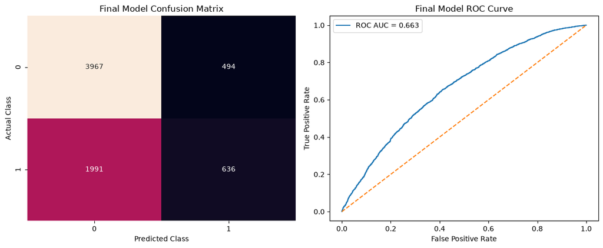

```python
# Calculate the confusion matrix and ROC curve

cm = confusion_matrix(y_test, y_pred)

fpr, tpr, _ = roc_curve(y_test, y_prob)
roc_auc = roc_auc_score(y_test, y_prob)

# Display model performance visually

fig, ax = plt.subplots(1, 2, figsize = (12, 5))

sns.heatmap(cm, annot = True, fmt = 'd', cbar = False, ax = ax[0])

ax[0].set_title('Final Model Confusion Matrix')
ax[0].set_xlabel('Predicted Class')
ax[0].set_ylabel('Actual Class')

ax[1].plot(fpr, tpr, label = f'ROC AUC = {roc_auc:.3f}')
ax[1].plot([0, 1], [0, 1], '--')
ax[1].set_title('Final Model ROC Curve')
ax[1].set_xlabel('False Positive Rate')
ax[1].set_ylabel('True Positive Rate')
ax[1].legend()

plt.tight_layout()
plt.show()
```

The confusion matrix shows the model's classification results at the default probability threshold of 0.50, while the ROC curve evaluates discrimination across all possible classification thresholds.

Because the audio features overlap substantially between popularity classes, the model should be interpreted as identifying patterns associated with popularity rather than providing a deterministic prediction of whether a song will become popular.

# Model Interpretation

Logistic regression coefficients were examined to identify which features have the strongest relationships with the predicted probability that a track exceeds the popularity threshold.

Because the continuous variables were standardized before modeling, their coefficients represent changes on a comparable standardized scale. Categorical coefficients represent differences relative to the reference category created during one-hot encoding.

```python
# Retrieve the feature names created during preprocessing

feature_names = final_model.named_steps['preprocessor'].get_feature_names_out()

# Retrieve the fitted logistic regression coefficients

coefficients = final_model.named_steps['classifier'].coef_[0]

coefficient_df = pd.DataFrame({
    'Feature': feature_names,
    'Coefficient': coefficients
})

# Clean the feature names created by the preprocessing pipeline

coefficient_df['Feature'] = (
    coefficient_df['Feature']
    .str.replace('continuous__', '', regex = False)
    .str.replace('categorical__', '', regex = False)
)

# Rank features by the size of their model coefficient

coefficient_df['Absolute Coefficient'] = coefficient_df['Coefficient'].abs()

top_coefficients = (
    coefficient_df
    .sort_values('Absolute Coefficient', ascending = False)
    .head(15)
)

top_coefficients[['Feature', 'Coefficient']].round(3)
```

|  | Feature | Coefficient |
| --- | --- | --- |
| 9 | playlist_genre_rock | 1.483 |
| 6 | playlist_genre_pop | 1.427 |
| 5 | playlist_genre_latin | 1.059 |
| 8 | playlist_genre_rap | 1.024 |
| 7 | playlist_genre_r&b | 0.679 |
| 1 | energy | -0.401 |
| 2 | loudness | 0.399 |
| 17 | key_8 | 0.144 |
| 4 | duration_min | -0.136 |
| 12 | key_3 | -0.118 |
| 14 | key_5 | 0.111 |
| 0 | danceability | 0.099 |
| 16 | key_7 | -0.084 |
| 19 | key_10 | 0.076 |
| 3 | tempo | 0.055 |

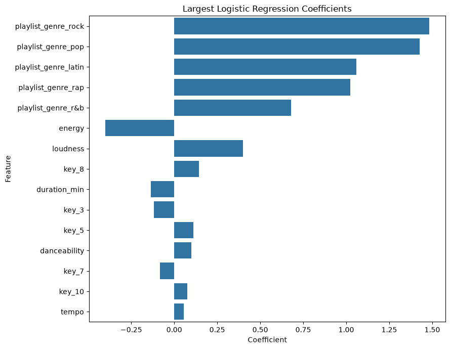

```python
# Visualize the largest logistic regression coefficients

fig, ax = plt.subplots(figsize = (9, 7))

sns.barplot(data = top_coefficients, x = 'Coefficient',
            y = 'Feature', ax = ax)

ax.set_title('Largest Logistic Regression Coefficients')
ax.set_xlabel('Coefficient')
ax.set_ylabel('Feature')

plt.tight_layout()
plt.show()
```

### Model Findings

Playlist genre produced the largest coefficients in the final logistic regression model. Rock, pop, Latin, rap, and R&B all showed strong positive relationships with the probability that a track exceeded the popularity threshold relative to the model's reference genre.

Among the continuous audio features, loudness had a positive coefficient while energy had a negative coefficient after controlling for the other variables in the model. Because energy and loudness are strongly correlated, these coefficients should be interpreted as their individual relationships with popularity while the other model features are held constant rather than as simple standalone effects.

Musical key, danceability, tempo, and duration produced comparatively smaller coefficients. Overall, the model reinforces the earlier exploratory finding that genre contributes substantial predictive information, while individual audio characteristics provide additional but more limited separation between popular and less-popular tracks.

The coefficients describe associations within this dataset and should not be interpreted as evidence that any particular genre or audio characteristic causes a song to become popular.

# Final Findings

Overall, song popularity is associated with combinations of genre and audio characteristics rather than any single measurable feature. These relationships are observational and should not be interpreted as evidence that particular audio characteristics cause a song to become popular.

# Data Source

The Spotify track dataset used in this analysis is available through the [R for Data Science TidyTuesday Spotify Songs dataset](https://github.com/rfordatascience/tidytuesday/tree/master/data/2020/2020-01-21).

The notebook retrieves the source data directly from the public repository so the analysis can be reproduced without requiring a separate local data file.